# Labour-Market Tightness and Slack in Australia

Author

Rimlan & Trisha

**Executive Summary**

This report investigates the relationship between labour-market tightness and slack in Australia, focusing on the research question: **To what extent are changes in job vacancies associated with short-run changes in labour-market slack in Australia?** Labour-market tightness reflects the availability of job opportunities relative to jobseekers, while labour-market slack represents unused labour capacity.

The analysis combines Australian Bureau of Statistics (ABS) job vacancy data with labour-market measures, including unemployment, underemployment and underutilisation. Job vacancies are used as an indicator of labour demand, while underutilisation is treated as the primary observable proxy for labour-market slack. The analysis examines changes over time, correlations between quarterly changes, the vacancy-to-unemployment ratio, and the relationship between labour-market conditions and wage price index growth.

The results show negative correlations between changes in job vacancies and changes in unemployment (−0.54), underemployment (−0.81) and underutilisation (−0.80). These results indicate that vacancy changes are more strongly associated with changes in underemployment and underutilisation than with unemployment in the analysed sample. The relationship between vacancy-based tightness and unemployment is also strong, although it requires careful interpretation because unemployment is used in the denominator of the tightness measure.

The wage analysis provides additional descriptive evidence about the relationship between labour-market conditions and wage growth. However, the results do not establish that changes in vacancies cause changes in slack or wages. Common economic influences, time trends, unusual periods and the construction of the indicators may affect the observed relationships.

Overall, the findings demonstrate the value of examining multiple indicators of labour-market slack rather than relying on unemployment alone. The report also highlights the importance of sensitivity analysis and careful interpretation when using labour-market indicators to inform economic analysis and policy discussions.

# 1 Introduction

Labour-market conditions are important for understanding economic activity, employment opportunities and wage pressures. When demand for workers is strong, employers may advertise more vacancies and face greater difficulty filling positions. At the same time, the economy may continue to have unused labour capacity, including people who are unemployed and people who are employed but would prefer to work additional hours. Consequently, unemployment alone may not provide a complete picture of labour-market conditions.

This report examines labour-market tightness and slack in Australia. Labour-market tightness describes the demand for workers relative to the available pool of unemployed jobseekers. Labour-market slack refers to unused labour capacity. In this analysis, slack is examined through three indicators: unemployment, underemployment and underutilisation. Unemployment captures people without a job who meet the relevant criteria for being unemployed; underemployment captures employed people who want and are available to work additional hours; and underutilisation provides a broader measure that incorporates both unemployed and underemployed people under the relevant statistical definitions.

The central research question is:

**To what extent are changes in job vacancies associated with short-run changes in labour-market slack in Australia?**

The analysis uses Australian Bureau of Statistics (ABS) job vacancy data as the primary indicator of labour demand and examines its relationship with changes in unemployment, underemployment and underutilisation. It also constructs a vacancy-to-unemployment ratio as an indicator of labour-market tightness. The analysis distinguishes between relationships in the levels of indicators and relationships in their changes, because these approaches describe different aspects of labour-market dynamics. Wage Price Index (WPI) growth is examined as an additional outcome to explore how labour-market conditions relate to wage growth over time.

The report has three broad objectives. First, it describes how Australian labour-market slack has evolved across different economic periods. Second, it quantifies the association between changes in vacancies and changes in alternative measures of slack. Third, it examines the tightness measure and its relationship with wage growth, while considering the limitations of these indicators.

The contribution of the analysis is to compare multiple measures of slack within a consistent empirical framework. This is important because unemployment, underemployment and underutilisation capture different aspects of unused labour capacity and may not respond identically to changing labour demand. The results may help inform how labour-market indicators are interpreted, although they are not intended to establish causal effects.

The remainder of the report is organised as follows. Section 2 explains the key concepts and economic context. Section 3 describes the data sources, measurement choices and exploratory analysis. Section 4 outlines the empirical methods, and Section 5 presents the results. Section 6 discusses the limitations of the analysis, before Section 7 concludes.

## 1.1 Background

The labour market plays an important role in the Australian economy by connecting employers seeking workers with individuals who are available and willing to work. Labour-market conditions change over time as the demand for workers and the availability of labour respond to economic conditions. Understanding these changes requires consideration of both the demand for labour and the extent to which available labour resources are being utilised.

Job vacancies provide an important indicator of labour demand because a higher level of vacancies generally reflects greater demand from employers for additional workers. In Australia, vacancy demand can be measured using both ABS Job Vacancies and the Jobs and Skills Australia (JSA) Internet Vacancy Index (IVI). These measures capture different aspects of recruitment activity. ABS Job Vacancies measures positions available for immediate filling at a particular point in time, while the IVI measures newly lodged online job advertisements during each month (Australian Bureau of Statistics, 2026). The distinction between these measures is important when considering their use in the analysis.

Labour demand alone does not provide a complete picture of labour-market conditions. The supply side is also important, particularly the amount of labour that is available but not fully utilised. This is commonly described as labour-market slack or labour underutilisation. Unemployment captures people without work who are actively seeking employment, but it does not include workers who are employed but would prefer and are available to work additional hours. The ABS therefore also reports underemployment and underutilisation. Underutilisation combines unemployment and underemployment and provides a broader measure of unused labour capacity.

Considering labour demand and labour-market slack together provides a more complete view of labour-market conditions. Periods of stronger demand for workers may coincide with lower levels of unused labour capacity, while weaker demand may coincide with greater labour-market slack. This motivates examining not only the individual trends in vacancies and slack, but also whether changes in these measures are associated with one another over time.

A related concept is labour-market tightness, which compares the demand for workers with the availability of unemployed workers. In this project, tightness is measured using the ratio of ABS Job Vacancies to unemployed persons. This provides a complementary perspective on labour-market conditions and is examined alongside the direct relationship between changes in vacancies and labour-market slack.

## 1.2 Research Motivation

Job vacancies, unemployment, underemployment and underutilisation provide different perspectives on Australian labour-market conditions. Examining these indicators together can provide a more complete understanding of labour demand and the extent to which available labour is being utilised.

The choice of measure is important because vacancy indicators capture different aspects of recruitment activity. The Jobs and Skills Australia (JSA) Internet Vacancy Index (IVI) measures newly lodged online job advertisements, whereas ABS Job Vacancies measures vacancies available for immediate filling at a particular point in time. Similarly, unemployment captures only one dimension of unused labour capacity, while underemployment and underutilisation provide broader perspectives on labour-market slack.

This project is motivated by the need to examine labour demand and labour-market slack jointly. In particular, analysing changes in job vacancies alongside changes in unemployment, underemployment and underutilisation allows the project to investigate whether movements in labour demand are associated with changes in unused labour capacity.

Labour-market tightness is also examined as a complementary indicator, providing an additional perspective on vacancies relative to the number of unemployed persons. However, the primary focus remains the association between changes in job vacancies and changes in labour-market slack.

## 1.3 Research Question

Based on this motivation, the main research question is:

**To what extent are changes in job vacancies associated with short-run changes in labour-market slack in Australia?**

The analysis focuses on association rather than causation. It examines the relationship between changes in job vacancies and three measures of labour-market slack: unemployment, underemployment and underutilisation. This comparison helps establish whether the observed relationship differs across narrower and broader measures of unused labour capacity.

Labour-market tightness is examined as a complementary measure, rather than a replacement for the direct analysis of job vacancies.

## 1.4 Research Objectives

The project has four main objectives:

1. Examine historical trends in Australian job vacancies and labour-market slack.
2. Compare unemployment, underemployment and underutilisation as measures of labour-market slack.
3. Assess the association between changes in job vacancies and changes in each measure of labour-market slack.
4. Examine labour-market tightness as a complementary indicator of labour-market conditions.

The analysis uses data from the Australian Bureau of Statistics (ABS) and Jobs and Skills Australia (JSA). ABS Job Vacancies and Labour Force data provide the primary measures for examining the relationship between vacancies and labour-market slack, while the JSA Internet Vacancy Index provides a complementary view of online recruitment activity, including patterns across occupations and skill levels. Supplementary analyses examine wage-related associations and the potential for short-term forecasting.

## 1.5 Report Structure

The remainder of this report is organised as follows. Section 2 introduces the key concepts of labour demand, labour-market slack and labour-market tightness. Section 3 describes the datasets, variable construction and exploratory analysis. Section 4 outlines the methodology, Section 5 presents the results, Section 6 discusses the limitations, and Section 7 concludes the report.

# 2 Concepts and Definitions

## 2.1 Labour Demand

Labour demand refers to employers’ demand for workers to produce goods and services. Job vacancies provide an observable indicator of unfilled positions for which employers are seeking workers. An increase in vacancies may indicate stronger recruitment demand, while a decrease may indicate weaker demand. However, vacancies do not measure all labour demand: they may also be affected by recruitment practices, job turnover, the difficulty of filling particular positions and changes in the composition of available jobs.

This report uses two vacancy indicators. The Australian Bureau of Statistics (ABS) Job Vacancies series measures the stock of vacancies at a point in time, whereas Jobs and Skills Australia’s Internet Vacancy Index (IVI) tracks online job advertisements. These measures provide related but distinct information. The ABS series is the primary vacancy measure for the quarterly analysis, while the IVI provides supplementary evidence about changes in online recruitment activity.

## 2.2 Labour-Market Slack

Labour-market slack refers to unused or underused labour capacity in the economy. It includes people who are unemployed and seeking work, as well as employed people who would prefer and are available to work additional hours. The ABS Labour Force Framework provides the statistical basis for classifying people according to their labour-force status (Australian Bureau of Statistics, 2021).

This report examines three indicators:

- **Unemployment:** people without a job who meet the ABS criteria for being unemployed, including relevant job-search and availability requirements.
- **Underemployment:** employed people who meet the relevant criteria for wanting and being available to work additional hours.
- **Underutilisation:** a broader indicator that combines unemployment and underemployment within the ABS’s published statistical framework.

These measures capture different aspects of the labour market. Unemployment focuses on people without work, whereas underemployment captures unused working-hour capacity among people who already have jobs. Underutilisation therefore provides a broader perspective on labour-market slack than unemployment alone (Australian Bureau of Statistics, 2021).

The indicators should not be interpreted as interchangeable. They may respond differently to changes in economic conditions because people can move between employment, unemployment and underemployment. For example, employers may reduce employees’ working hours without immediately increasing unemployment. In this situation, underemployment may rise even if the unemployment rate changes relatively little.

## 2.3 Labour-Market Tightness

Labour-market tightness describes the balance between employers’ demand for workers and the available pool of unemployed jobseekers. A relatively tight labour market has more vacancies relative to unemployed people, while a less tight market has fewer vacancies relative to the number of unemployed people.

In this report, tightness is measured using the ratio of ABS Job Vacancies to the number of unemployed people. The ratio provides a simple indicator of vacancies relative to unemployed jobseekers and allows conditions to be compared over time.

However, this ratio is not a complete measure of the balance between labour demand and labour supply. It does not account directly for underemployed workers, people entering or leaving the labour force, differences in skills, or the geographical distribution of vacancies and jobseekers. It should therefore be interpreted as an indicator of tightness rather than a comprehensive measure of all available labour supply.

A further consideration is that unemployment appears in the denominator of the ratio. Consequently, the relationship between the tightness ratio and unemployment is partly mechanical: a fall in unemployment increases the ratio even if vacancies remain unchanged. This limitation is considered when interpreting the empirical results.

## 2.4 Expected Relationship Between Vacancies and Slack

Economic reasoning suggests that stronger labour demand may coincide with lower labour-market slack. When employers advertise more vacancies, unemployed people may have more opportunities to find work. Underemployment may also decline if employers increase the hours offered to existing workers.

Accordingly, this report expects changes in vacancies to be negatively associated with changes in unemployment, underemployment and underutilisation. However, the strength of these relationships need not be the same across the three indicators. Underemployment may capture adjustments in working hours that are not reflected immediately in unemployment.

These expected relationships are hypotheses to be examined empirically, not conclusions assumed in advance. Vacancy movements and labour-market slack may both respond to broader economic conditions, and the timing of their responses may differ. The analysis therefore investigates statistical associations and does not interpret correlations as evidence of causation.

## 2.5 Summary of the Conceptual Framework

The analysis treats vacancies as an indicator of labour demand and unemployment, underemployment and underutilisation as indicators of unused labour capacity. The vacancy-to-unemployment ratio provides a separate summary measure of labour-market tightness. Comparing these indicators helps establish whether the relationship between recruitment demand and labour-market slack depends on how slack is measured.

The central empirical question is whether changes in vacancies are associated with changes in the three slack indicators, and whether the strength of the association differs across them. The analysis also considers wage growth as an extension, while recognising that wages may respond to labour-market conditions with a delay and are influenced by other economic factors.

# 3 Data and Measurement

## 3.1 Jobs and Skills Australia Internet Vacancy Index

### 3.1.1 Data Source and Collection

The Internet Vacancy Index (IVI), published by Jobs and Skills Australia (JSA), is used in this project as a monthly indicator of labour demand in Australia. The IVI measures online job advertisements newly lodged during each reference month on three contributing job boards: SEEK, CareerOne and Workforce Australia (Jobs and Skills Australia, 2026).

The IVI is based on administrative data provided by the contributing job boards rather than data collected through an employer survey. JSA processes the advertisements and classifies them by occupation, skill level and geographical location. Duplicate advertisements posted on the same or multiple contributing job boards are removed during this process (Jobs and Skills Australia, 2026).

### 3.1.2 Measurement and Coverage

The IVI is available as a monthly time series from January 2006. The data provide information by occupation, skill level, state and territory, and regional areas. For the national labour-demand analysis in this project, the seasonally adjusted Australian total series is used.

An important characteristic of the IVI is that it measures newly lodged advertisements during a month. It therefore represents a flow of online recruitment activity rather than the stock of vacancies that remain unfilled at a particular point in time (Jobs and Skills Australia, 2026).

### 3.1.3 Limitations of the IVI

The IVI does not represent all vacancies in the Australian labour market. It only includes advertisements from the contributing online job boards and therefore excludes recruitment through other job boards, employer websites, social media, newspapers and informal methods such as word of mouth. In addition, one advertisement may represent multiple available positions, while some vacancies may be filled without being advertised online (Jobs and Skills Australia, 2026).

For these reasons, the IVI is interpreted in this project as an indicator of online recruitment activity and labour demand rather than a complete measure of all job vacancies in Australia.

## 3.2 ABS Job Vacancies

### 3.2.1 Job Vacancies Survey

The second measure of labour demand is obtained from the Australian Bureau of Statistics (ABS) Job Vacancies Survey (JVS). Unlike the IVI, which is based on online job advertisements, the JVS collects information directly from a sample of employing organisations. Approximately 4,000 statistical units are selected from the ABS Business Register, with data collected through online electronic collection and/or telephone interviews (Australian Bureau of Statistics, 2026).

The ABS defines a job vacancy as a job that is available for immediate filling on the survey reference date and for which recruitment action has been taken (Australian Bureau of Statistics, 2026).

### 3.2.2 Measurement and Coverage

The JVS is conducted quarterly. Its reference date is the third Friday of the middle month of each quarter, corresponding to February, May, August and November. The number of vacancies therefore refers to vacancies existing on a particular reference date rather than vacancies accumulated over the entire quarter (Australian Bureau of Statistics, 2026).

For this project, the seasonally adjusted Australian total job-vacancy series is used. ABS classifies job vacancies as a stock measure because they are measured at a specific point in time (Australian Bureau of Statistics, 2026).

There are five missing quarterly observations between August 2008 and August 2009 because the Job Vacancies Survey was suspended after May 2008 and reinstated in November 2009. These observations are retained as missing rather than being imputed, as the ABS does not provide official estimates for the gap period (Australian Bureau of Statistics, 2026).

### 3.2.3 IVI versus ABS Job Vacancies

Although both series provide information about labour demand, they measure different concepts. The IVI counts newly lodged online job advertisements during a month and is therefore a flow measure of recruitment activity. In contrast, ABS Job Vacancies measures the number of vacancies available for immediate filling on a particular reference date and is therefore a stock measure (Jobs and Skills Australia, 2026; Australian Bureau of Statistics, 2026).

This distinction is important for the analysis. The IVI is used to examine monthly changes in recruitment demand, while ABS Job Vacancies is used in constructing the quarterly labour-market tightness measure. Using ABS Job Vacancies for the tightness measure provides a more consistent comparison with the number of unemployed persons, since both represent quantities measured for a particular reference period.

## 3.3 ABS Labour Force Data

The analysis of labour-market slack uses data from the Australian Bureau of Statistics (ABS) Labour Force Survey. The Labour Force Survey provides monthly measures of employment, unemployment, underemployment and labour-force participation for the Australian population aged 15 years and over. These measures provide the basis for constructing observable indicators of labour-market slack over time (Australian Bureau of Statistics, 2026).

### 3.3.1 Data Source and Labour-Market Measures

The analysis of labour market slack uses data from the Australian Bureau of Statistics (ABS) Labour Force Survey. The Labour Force Survey provides monthly measures of employment, unemployment, underemployment and labour-force participation for the Australian population aged 15 years and over. These measures provide the basis for constructing observable indicators of labour market slack over time.

Three measures are central to this analysis. The unemployment rate captures the proportion of the labour force that is unemployed, while the underemployment rate captures employed people who want and are available to work additional hours. The underutilisation rate combines unemployment and underemployment and provides a broader measure of labour underutilisation.

The analysis retains unemployment and underemployment as separate measures while using underutilisation as the primary proxy for overall labour market slack. This approach allows the analysis to distinguish between different forms of unused labour capacity rather than relying on unemployment alone.

### 3.3.2 Measurement of Labour-Market Slack

Labour market slack is not directly observed as a single variable. Instead, it is approximated using observable measures of labour underutilisation. In this study, underutilisation is used as the main proxy because it incorporates both unemployment and underemployment.

This distinction is important because unemployment alone may understate available labour capacity. An individual who is employed but wants and is available to work additional hours is not classified as unemployed, but their unused working time capacity is captured through underemployment. Including underemployment therefore provides a broader perspective on labour market slack.

The analysis also examines unemployment and underemployment separately. This enables changes in overall underutilisation to be interpreted in terms of whether they are associated primarily with changes in unemployment, changes in the availability of additional working hours, or movements in both measures.

### 3.3.3 Data Period and Frequency

For the historical analysis, the data are grouped into six broad periods: 1978-1989, 1990-1994, 1995-2007, 2008-2019, 2020-2021 and 2022 onwards. These periods provide a basis for comparing labour market conditions across different phases of the Australian economy, including the early 1990s recession and the COVID-19 period.

The monthly frequency of the Labour Force Survey also allows changes in unemployment, underemployment and underutilisation to be examined at a relatively detailed time scale. For the analysis of the labour market tightness, the monthly labour force measures are aligned with the quarterly ABS Job Vacancies data to construct the vacancy to unemployment ratio.

### 3.3.4 Measurement Considerations

The ABS Labour Force measures provide consistent and widely used indicators of labour market conditions, but they do not capture every dimension of unused labour capacity. In particular, underutilisation does not represent all potential forms of labour market slack, such as the capacity of people who are outside the labour force to enter employment or changes in workers preferred working arrangements that are not reflected in the standard measures.

Underutilisation should therefore be interpreted as an observable proxy for labour market slack rather than a complete measure of unused labour resources. This limitation is important when interpreting the relationship between labour market tightness and slack. The analysis focuses on statistical associations between labour-market tightness and slack and does not interpret these relationships as evidence of causality.

## 3.4 Labour-Market Tightness

### 3.4.1 Vacancy-to-Unemployment Ratio

Labour-market tightness is used to represent the balance between labour demand and the availability of unemployed workers. In this project, tightness is initially measured using the vacancy-to-unemployment ratio:

$$\text{Labour-market tightness}_t =
\frac{\text{Job Vacancies}_t}
{\text{Unemployed Persons}_t}$$

A higher value indicates that there are more job vacancies relative to the number of unemployed persons, representing a tighter labour market. Conversely, a lower value indicates fewer vacancies relative to unemployed persons.

### 3.4.2 Construction of the Measure

The numerator is the seasonally adjusted Australian total ABS Job Vacancies series, while the denominator is the seasonally adjusted number of unemployed persons from the ABS Labour Force data.

Because Job Vacancies data are quarterly while Labour Force data are monthly, unemployed-person observations are matched to the corresponding vacancy reference months of February, May, August and November. Both series are measured in thousands of persons or positions, so the units cancel when the ratio is calculated.

The resulting measure provides a quarterly series of labour-market tightness that can subsequently be compared with the measures of labour-market slack used in this project.

## 3.5 ABS Job Vacancies Over Time

The ABS Job Vacancies series provides a quarterly view of labour demand in Australia. Figure Figure 1 shows the seasonally adjusted number of job vacancies over the study period.

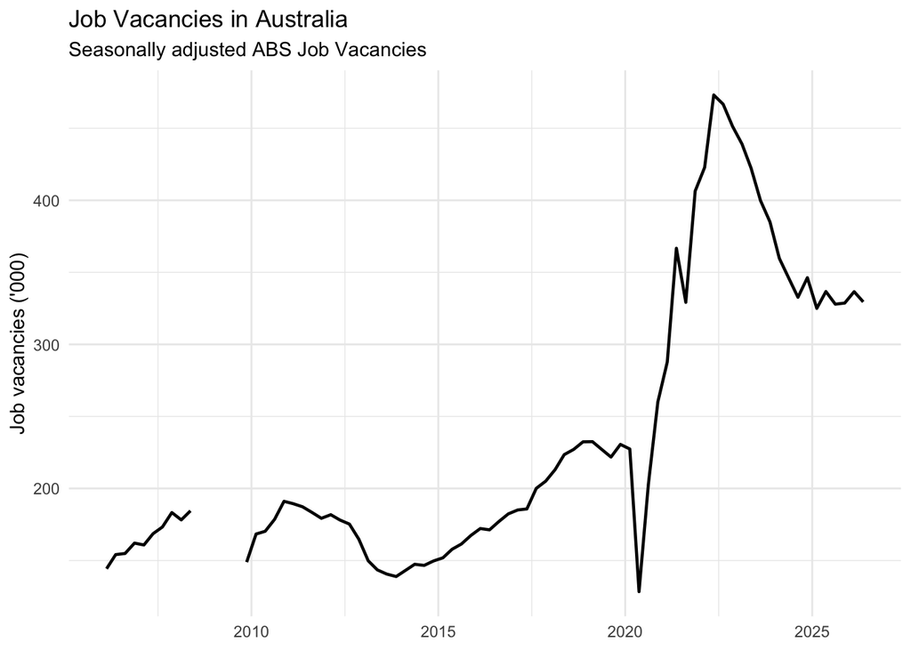

Figure 1: Seasonally adjusted job vacancies in Australia

A particularly large decline is visible in 2020, followed by a strong increase during 2021 and 2022. Job vacancies reached their highest levels around 2022 before declining over the following years.

These patterns indicate that labour demand has varied substantially over time. However, the figure is descriptive and does not by itself establish the causes of these movements.

## 3.6 Internet Vacancy Index Over Time

The Internet Vacancy Index provides a higher-frequency view of recruitment activity because it records newly lodged online job advertisements each month. Figure Figure 2 shows the seasonally adjusted Australian total IVI.

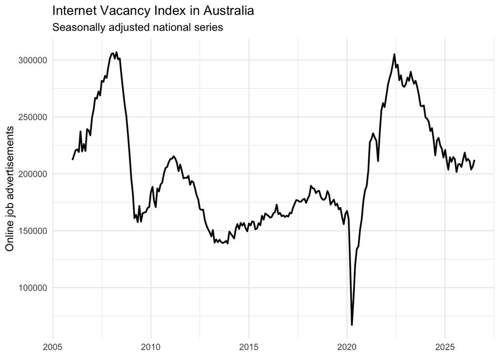

Figure 2: Internet Vacancy Index for Australia

The IVI also shows substantial variation in recruitment activity over time. Online job advertisements increased during the earlier part of the series before declining around 2008–2009. Recruitment activity subsequently recovered, although further periods of decline and recovery are visible.

One of the most pronounced movements occurs in 2020, when the IVI falls sharply. This is followed by a strong increase, with recruitment activity reaching particularly high levels around 2022. The index subsequently declines through the following years.

The broad movements are similar to those observed in ABS Job Vacancies. However, the two series should not be interpreted as identical measures. The IVI measures the flow of newly lodged online advertisements each month, whereas ABS Job Vacancies measures the stock of vacancies available for immediate filling at a reference date (Jobs and Skills Australia, 2026; Australian Bureau of Statistics, 2026).

## 3.7 Vacancy Patterns by Occupation

While the national IVI shows changes in overall recruitment activity, labour demand is not evenly distributed across occupations. The broad occupation-level IVI data are therefore examined to compare recruitment activity across major occupational groups.

The latest available observation is used to provide a snapshot of the occupational composition of online recruitment demand.

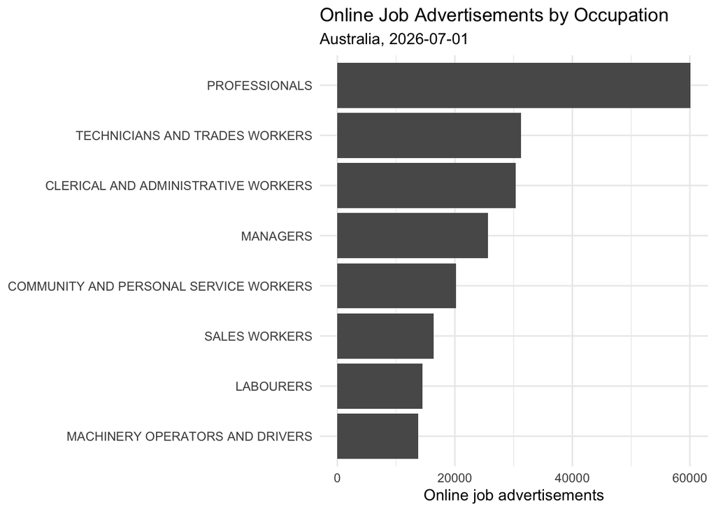

Figure 3: Online job advertisements by broad occupation group

Figure Figure 3 shows that online recruitment demand differs substantially across broad occupational groups. Professionals recorded the highest number of online job advertisements in the latest observation, indicating particularly high recruitment activity within this broad occupational category.

Other occupational groups also account for substantial numbers of advertisements, demonstrating that labour demand is distributed across multiple parts of the Australian labour market. The differences across occupations are important because movements in aggregate vacancy measures may reflect different recruitment conditions across occupational groups.

These results describe the composition of online recruitment activity rather than the total number of vacancies in each occupation. As discussed in Section 3, the IVI only captures newly lodged advertisements from the contributing online job boards and should therefore be interpreted as an indicator of recruitment activity (Jobs and Skills Australia, 2026).

## 3.8 Labour-Market Slack Over Time

The ABS Labour Force data provide a long-run view of labour-market slack in Australia. Figure Figure 4 presents monthly unemployment, underemployment and underutilisation rates from February 1978 to July 2026. In this analysis, underutilisation is used as the primary observable proxy for labour-market slack, while unemployment and underemployment are examined separately to distinguish the different components of unused labour capacity.

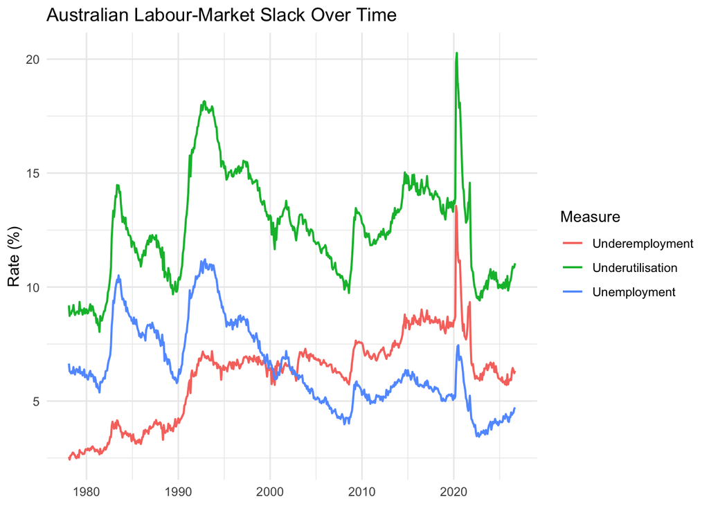

Figure 4: Unemployment, underemployment and underutilisation in Australia

The three measures display substantial variation over the study period and illustrate why unemployment alone may not capture the full extent of unused labour capacity. Unemployment measures people who are without work and actively seeking and available for work, whereas underemployment captures employed people who want and are available for additional hours. Underutilisation combines unemployment and underemployment and therefore provides a broader measure of labour underutilisation.

To compare labour-market conditions across different stages of the sample, the analysis divides the period into six broad intervals: 1978–1989, 1990–1994, 1995–2007, 2008–2019, 2020–2021 and 2022 onwards. Table Table 1 summarises the average unemployment, underemployment and underutilisation rates for each period.

Table 1: Average labour-market slack measures by period

| Period | Observations | Unemployment (%) | Underemployment (%) | Underutilisation (%) |
| --- | --- | --- | --- | --- |
| 1978–1989 | 143 | 7.37 | 3.36 | 10.73 |
| 1990–1994 | 60 | 9.58 | 6.12 | 15.70 |
| 1995–2007 | 156 | 6.52 | 6.61 | 13.13 |
| 2008–2019 | 144 | 5.41 | 7.71 | 13.12 |
| 2020–2021 | 24 | 5.81 | 9.30 | 15.11 |
| 2022–present | 57 | 3.99 | 6.19 | 10.18 |

The period averages show that the level and composition of labour-market slack have varied considerably across the sample. During 1978–1989, average unemployment was 7.37%, while underemployment averaged 3.36%, resulting in average underutilisation of 10.7%. Labour-market slack was higher during 1990–1994, when average unemployment increased to 9.58% and average underutilisation reached 15.7%. The period also recorded a peak unemployment rate of approximately 11.2% and a peak underutilisation rate of approximately 18.2%.

Between 1995 and 2007, average unemployment declined to 6.52%, while average underemployment increased to 6.60%. Average underutilisation was 13.1%. A similar pattern is evident between 2008 and 2019. Average unemployment declined further to 5.41%, while underemployment increased to 7.71%, leaving average underutilisation at approximately 13.1%. These results indicate that reductions in unemployment were not always accompanied by equivalent reductions in broader labour underutilisation.

Overall, the historical analysis demonstrates that labour-market slack is not captured fully by unemployment alone. Although periods of elevated slack have generally coincided with higher unemployment, underemployment has also contributed substantially to total labour underutilisation, particularly in more recent periods. Underutilisation therefore provides a broader observable measure for the subsequent analysis, while unemployment and underemployment are retained as separate measures to examine the composition of slack.

## 3.9 Labour-Market Tightness Over Time

Job vacancies alone do not account for the number of workers available in the labour market. The vacancy-to-unemployment ratio constructed in Section 3 provides an additional perspective by measuring the number of job vacancies relative to the number of unemployed persons.

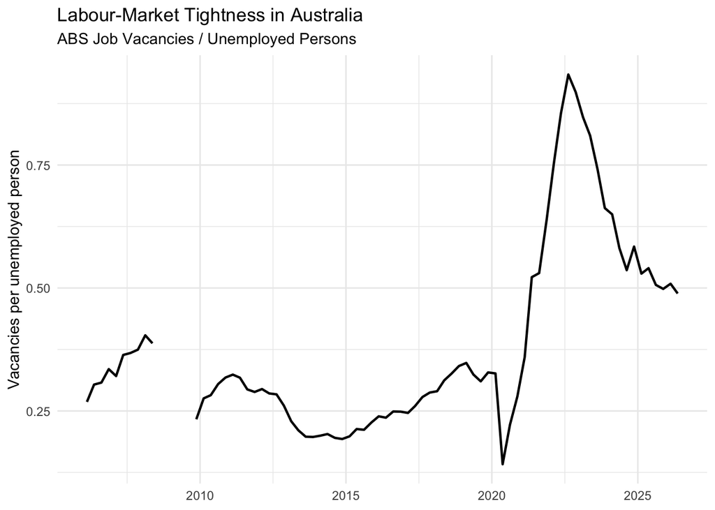

Figure 5: Labour-market tightness in Australia

Figure Figure 5 shows substantial variation in labour-market tightness over the study period. The ratio was particularly low around early 2020, indicating that there were relatively few job vacancies compared with the number of unemployed persons. Tightness then increased rapidly and reached its highest level in 2022.

Following the 2022 peak, labour-market tightness generally declined. By May 2026, the ratio was approximately 0.49, meaning that there were approximately 0.49 job vacancies for every unemployed person.

The tightness measure therefore provides additional information beyond the vacancy series alone. An increase in job vacancies does not necessarily represent the same labour-market conditions if the number of unemployed persons is also changing. Considering vacancies relative to unemployment allows labour demand to be interpreted in relation to the available unemployed workforce.

The five missing observations between August 2008 and August 2009 correspond to the period in which the ABS Job Vacancies Survey was suspended. These observations remain missing in the tightness series rather than being imputed (Australian Bureau of Statistics, 2026).

## 3.10 Labour-Market Tightness and Slack

To provide an initial view of the relationship between labour-market tightness and slack, the quarterly tightness measure is compared with unemployment, underemployment and underutilisation. Figure Figure 6 shows the relationship across the three measures.

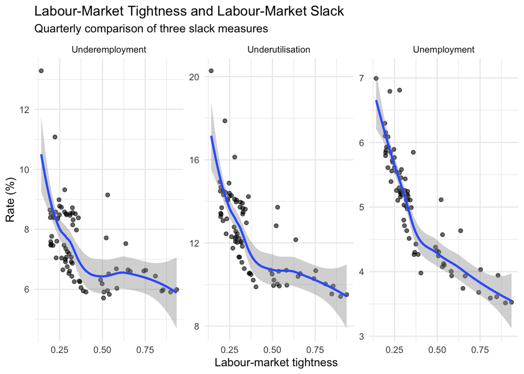

Figure 6: Labour-market tightness and measures of labour-market slack

The three panels show an overall negative relationship between labour-market tightness and each measure of labour-market slack. Periods with higher tightness generally coincide with lower unemployment, underemployment and underutilisation.

The LOESS trends show that these relationships are not fully linear, with the pattern differing across the three measures. This provides an initial descriptive indication that tighter labour-market conditions are associated with lower levels of unused labour capacity.

These plots are descriptive and do not establish a causal relationship. The relationship is examined further in the subsequent analysis.

# 4 Methodology

This section describes the analytical approach used to examine the relationship between job vacancies and labour-market slack in Australia. The analysis is primarily descriptive and focuses on identifying how measures of labour demand and labour-market slack move together over time. Particular attention is given to changes in the variables because the research question asks to what extent changes in job vacancies are associated with changes in labour-market slack.

## 4.1 Analytical Framework

The analysis considers labour-market conditions from both the demand and slack sides of the labour market. Labour demand is represented by job vacancy measures, while labour-market slack is represented by unemployment, underemployment and underutilisation.

Two measures of labour demand are available in the project. The Jobs and Skills Australia Internet Vacancy Index (IVI) provides a monthly indicator of newly lodged online job advertisements, while ABS Job Vacancies provides a quarterly stock measure of vacancies available for immediate filling. As discussed in Section 3, these measures capture different concepts and are therefore not treated as interchangeable.

ABS Job Vacancies are also combined with unemployed persons to construct the vacancy-to-unemployment ratio:

$$\text{Labour-Market Tightness}_t =
\frac{\text{Job Vacancies}_t}
{\text{Unemployed Persons}_t}$$

A higher value indicates that there are more vacancies relative to the number of unemployed persons, while a lower value indicates fewer vacancies relative to unemployed persons.

The analytical framework therefore examines the labour market from three related perspectives: vacancy activity as an indicator of labour demand, unemployment, underemployment and underutilisation as measures of labour-market slack, and the vacancy-to-unemployment ratio as a complementary measure of labour-market tightness.

The analysis focuses on statistical association rather than causality. Observed relationships between vacancies, tightness and slack are therefore interpreted as evidence that the variables move together, rather than evidence that changes in one variable directly cause changes in another.

## 4.2 Data Alignment

The variables used in the analysis are reported at different frequencies. The IVI and ABS Labour Force measures are available monthly, whereas ABS Job Vacancies are available quarterly.

For analyses involving ABS Job Vacancies and labour-market tightness, the monthly Labour Force observations are aligned with the corresponding ABS Job Vacancies reference months: February, May, August and November. This produces a quarterly dataset in which vacancy and slack measures refer to corresponding periods.

The five unavailable ABS Job Vacancies observations between August 2008 and August 2009 are retained as missing values rather than being estimated or interpolated. Consequently, observations requiring Job Vacancies or labour-market tightness are also unavailable for these periods.

This alignment allows job vacancies, labour-market tightness and the three measures of labour-market slack to be compared on a consistent quarterly basis.

## 4.3 Levels and Changes

The analysis considers both the levels of the labour-market indicators and their changes over time.

Analysis in levels is used to examine whether periods of relatively high labour demand or labour-market tightness tend to coincide with relatively high or low levels of labour-market slack. This provides an initial description of the relationship between the variables.

Because the research question focuses on changes in job vacancies and labour-market slack, quarter-to-quarter changes are also considered in the subsequent analysis. For a variable $X_t$, the change between consecutive observations is defined as:

$$\Delta X_t = X_t - X_{t-1}$$

A positive value represents an increase from the previous observation, while a negative value represents a decrease. Examining changes allows the analysis to focus on movements in the labour-market indicators rather than only comparing their absolute levels.

## 4.4 Correlation Analysis

Pearson correlation coefficients are used as the primary descriptive measure of association. Spearman rank correlations are also calculated as a sensitivity check because they are less sensitive to extreme observations and do not require a linear relationship.

Scatter plots and regression diagnostics were also examined to assess whether a linear relationship was appropriate. Where the diagnostics indicated non-linear patterns, LOESS was used to provide a more flexible representation of the relationship.

The correlation coefficient ranges from -1 to 1. A positive coefficient indicates that two variables tend to move in the same direction, while a negative coefficient indicates that they tend to move in opposite directions. Values closer to zero indicate a weaker linear association.

Correlations are examined for the labour-market indicators in levels and for their changes over time. The three measures of labour-market slack are considered separately so that the relationship is not assessed using unemployment alone.

Particular care is required when interpreting the relationship between labour-market tightness and unemployment because unemployed persons are included in the denominator of the tightness measure. Consequently, part of the negative relationship between these two variables may arise mechanically from the construction of the ratio. Comparisons with underemployment and underutilisation provide additional evidence because these measures are not directly used in the calculation of the tightness ratio.

The correlations are interpreted as measures of association only. A strong correlation does not establish that changes in vacancies or labour-market tightness cause changes in labour-market slack.

## 4.5 Analysis of Changes

The analysis considers both the levels and changes of labour-market indicators. While analysis in levels provides information about whether periods of relatively high labour-market tightness tend to coincide with higher or lower levels of labour-market slack, the research question focuses specifically on changes in job vacancies and changes in labour market slack. The analysis of changes therefore provides a closer match to the main research question.

For each labour market variable, the change between consecutive quarterly observations is calculated as:

$$\Delta X_t = X_t - X_{t-1}$$
where $X_t$ represents the value of the variable in the current quarter and $X_{t-1}$ represents its value in the previous quarter. A positive value therefore represents an increase relative to the previous quarter, while a negative value represents a decrease.

This transformation is applied to labour market tightness and the three measures of labour market slack. The change in tightness is calculated as :

$$\Delta T_t = T_t - T_{t-1}$$
where $T_t$ represents the vacancy-to-unemployment ratio. Changes in unemployment, underemployment and underutilisation are calculated similarly:
$$\Delta U_t = U_t - U_{t-1}$$
$$\Delta UE_t = UE_t - UE_{t-1}$$
$$\Delta UR_t = UR_t - UR_{t-1}$$
where $U_t$ denotes the unemployment rate, $UE_t$ denotes the underemployment rate and $UR_t$ denotes the underutilisation rate.

The change-based analysis is used to examine whether periods in which labour-market tightness increases or decreases are associated with corresponding movements in labour-market slack. This reduces the emphasis on long-run differences in the level of the variables and instead focuses on quarter-to-quarter movements.

The change analysis remains descriptive. A correlation between changes in two variables indicates that their movements are associated over the period examined, but it does not establish that a change in one variable causes a change in the other.

## 4.6 Timing and Lagged Relationships

The analysis also examines whether relationships between labour market conditions and wage growth occur contemporaneously or with a time lag. This is relevant because changes in labour market tightness or slack may not be reflected immediately in wage outcomes. Employers and workers may take time to adjust wages following changes in labour market conditions.

To examine the timing of these relationships, correlations are calculated between labour market indicators in the current quarter and Wage Price Index (WPI) growth in the same quarter and subsequent quarters. The same quarter relationship is represented as :

$$Corr(X_t, Y_t)$$
where $X_t$ represents the labour market indicator in quarter $t$ and $Y_t$ represents WPI growth in the same quarter.

A one-quarter ahead relationship is calculated as:

$$Corr(X_t, Y_{t+1})$$

where WPI growth occurs one quarter after the labour market indicator. A two-quarter ahead relationship is similarly calculated as:

$$Corr(X_t, Y_{t+2})$$

where WPI growth occurs two quarters after the labour-market indicator.

This approach is applied to labour market tightness and underutilisation. Tightness represents the number of job vacancies relative to unemployed persons, while underutilisation provides the primary observable measure of labour market slack. WPI growth is calculated as the percentage change in the Wage Price Index between consecutive quarters:

$$g_t =
\left(
\frac{WPI_t}{WPI_{t-1}} - 1
\right) \times 100$$

The timing analysis is intended to identify whether the statistical association between labour market conditions and wage growth is stronger contemporaneously or at subsequent quarters. It does not constitute a forecasting model and does not establish that changes in labour market conditions cause subsequent changes in wages. The results are therefore interpreted as evidence of the timing and strength of statistical associations within the sample.

The analysis also provides a complementary perspective on the relationship between labour market tightness, labour market slack and wage outcomes. If the relationship between tightness and WPI growth is stronger at subsequent quarters, this may indicate that wage growth is more closely associated with earlier labour market conditions than with conditions measured in the same quarter. Similarly, differences in the timing of the underutilisation relationship provide information about how broader labour market slack and wage growth move together over time.

# 5 Results

This section presents the empirical results of the analysis. The results first examine the relationship between labour-market tightness and the three measures of labour-market slack. The subsequent analyses consider quarter-to-quarter changes, differences across occupations and skill levels, and the relationship between labour-market conditions and wage growth. The relationship between labour-market conditions and wage growth is considered as an extension.

## 5.1 Changes in Job Vacancies and Labour-Market Slack

To address the research question directly, quarter-to-quarter changes in job vacancies were compared with changes in unemployment, underemployment and underutilisation. Focusing on changes allows the analysis to examine whether short-run movements in labour demand are associated with short-run movements in labour-market slack.

Table 2: Pearson and Spearman correlations between quarterly changes in job vacancies and labour-market slack

| Slack measure | Pearson | Spearman |
| --- | --- | --- |
| Unemployment | -0.54 | -0.39 |
| Underemployment | -0.81 | -0.51 |
| Underutilisation | -0.80 | -0.56 |

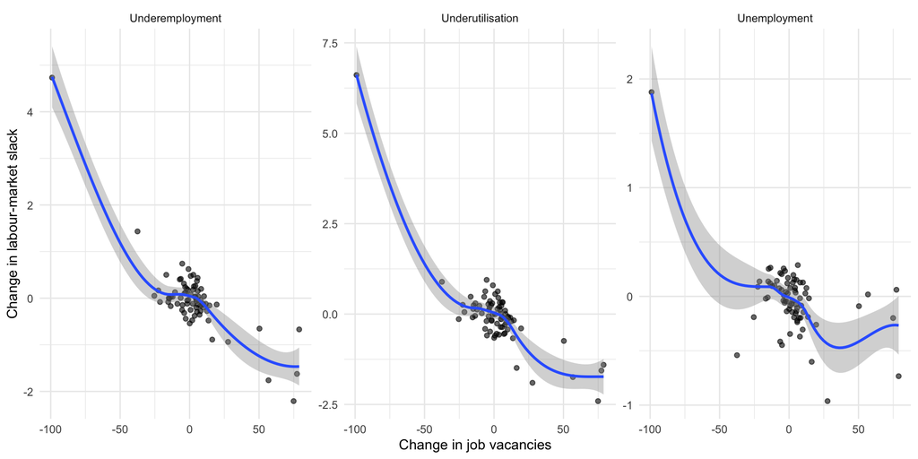

Figure 7: Changes in job vacancies and labour-market slack

Table Table 2 shows negative associations between changes in job vacancies and all three measures of labour-market slack. The Pearson correlations are -0.54 for unemployment, -0.81 for underemployment and -0.80 for underutilisation.

Figure Figure 7 also shows an overall negative association. The LOESS trends indicate that the relationships are not fully linear, particularly for unemployment and underutilisation.

As a sensitivity check, Spearman correlations were also calculated and remained negative for unemployment (-0.39), underemployment (-0.51) and underutilisation (-0.56), although weaker than the Pearson correlations. This indicates that the inverse relationship remains under an alternative correlation measure, although its estimated strength is sensitive to the method used. These relationships are descriptive and do not establish causation.

## 5.2 Labour-Market Tightness and Labour-Market Slack

As a complementary analysis, labour-market tightness was compared with unemployment, underemployment and underutilisation. Unlike job vacancies alone, the tightness measure considers the number of vacancies relative to the number of unemployed persons.

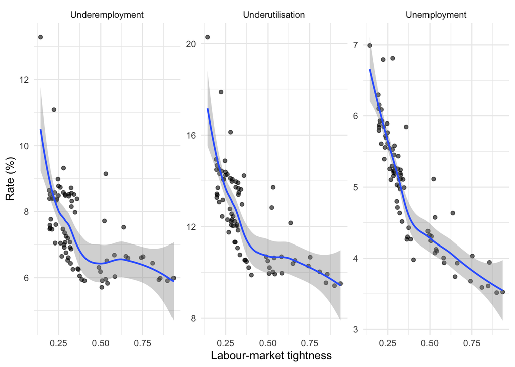

Figure 8: Relationship between labour-market tightness and measures of labour-market slack

Figure Figure 8 shows an overall negative association between labour-market tightness and all three measures of labour-market slack. The correlations are approximately -0.85 for unemployment, -0.55 for underemployment and -0.70 for underutilisation. The LOESS trends also indicate that these relationships are not fully linear.

Periods with higher labour-market tightness generally coincided with lower unemployment, underemployment and underutilisation. However, the strong relationship with unemployment should be interpreted cautiously because unemployed persons are included in the denominator of the tightness measure, creating a partly mechanical relationship.

Overall, the results support the main finding in Section 5.1 that stronger labour-market conditions are generally associated with lower labour-market slack. These relationships are descriptive and do not establish causation.

## 5.3 Changes in Labour-Market Tightness and Slack

To examine whether the relationship between labour-market tightness and slack also appears in short-run movements, quarter-to-quarter changes in tightness were compared with changes in unemployment, underemployment and underutilisation.

Table 3: Correlation between quarterly changes in labour-market tightness and slack

| Slack measure | Correlation |
| --- | --- |
| Unemployment | -0.77 |
| Underemployment | -0.68 |
| Underutilisation | -0.77 |

Table Table 3 shows negative correlations between changes in labour-market tightness and changes in all three measures of slack. The correlations are approximately **-0.77** for unemployment, **-0.68** for underemployment and **-0.77** for underutilisation.

This indicates that quarters with increasing labour-market tightness generally coincided with reductions in labour-market slack. The similar negative relationships across the three measures suggest that the inverse relationship is not limited to unemployment alone.

Together with Section 5.2, these results show that the negative relationship between tightness and slack is visible both in their levels and in their short-run movements. However, these correlations describe contemporaneous associations and do not establish causation.

## 5.4 Differences Across Occupations and Skill Levels

The aggregate vacancy measures used in the previous sections may conceal differences in labour demand across different parts of the labour market. To explore this variation, Internet Vacancy Index (IVI) data were examined across broad occupation groups and skill levels using the latest available national observation.

### 5.4.1 Broad Occupation Groups

The latest available national observation was used to compare online job vacancies across broad occupation groups.

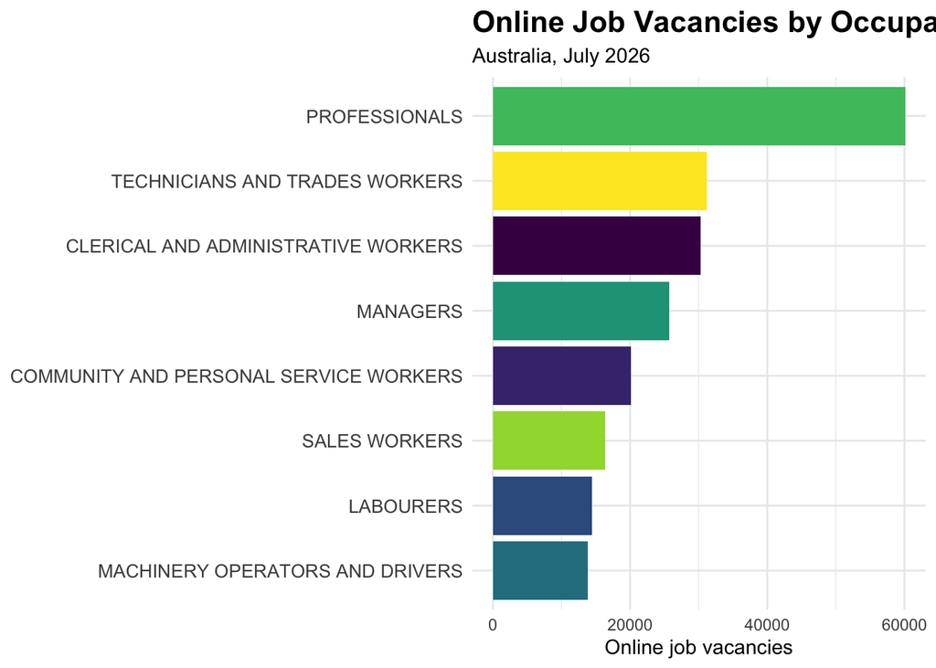

Figure 9: Online job vacancies by broad occupation group in the latest available observation

Figure Figure 9 shows that online job vacancies are not evenly distributed across broad occupation groups. Professionals recorded the highest number of vacancies in the latest available observation, followed by Technicians and Trades Workers and Clerical and Administrative Workers. Machinery Operators and Drivers and Labourers recorded comparatively lower vacancy levels.

These differences show that aggregate vacancy measures can conceal substantial variation in labour demand across occupations. Therefore, changes in total vacancies may reflect different labour-demand conditions across different parts of the labour market.

### 5.4.2 Skill Levels

Vacancy levels were also compared across skill levels to examine whether labour demand was distributed evenly across different skill requirements.

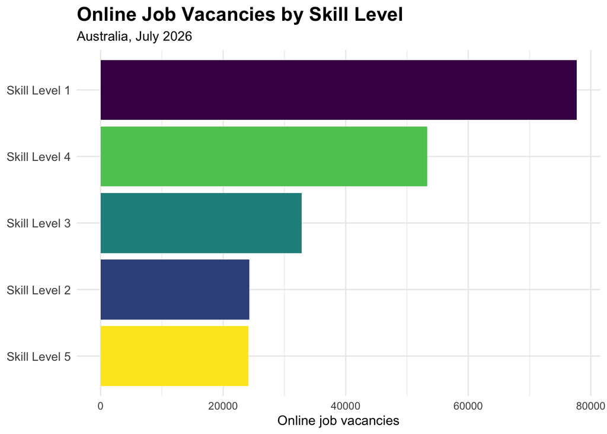

Figure 10: Online job vacancies by skill level in the latest available observation

Figure Figure 10 shows that online job vacancies also differ across skill levels. Skill Level 1 recorded the highest vacancy level among the five skill-level categories in the latest available observation, while the remaining skill levels recorded lower levels of vacancies.

Together, the occupation and skill-level results indicate that labour demand is not distributed uniformly across the Australian labour market. This provides additional context for the aggregate results in the previous sections: movements in overall vacancies may conceal different labour-demand conditions across occupations and skill requirements.

However, this analysis provides a cross-sectional snapshot of the latest available observation rather than evidence that occupation or skill-level differences explain the aggregate relationship between vacancies and labour-market slack. Further analysis would be required to directly link occupation- or skill-specific vacancy patterns with corresponding measures of labour-market slack.

## 5.5 Wage Price Index Extension

As a supplementary analysis, the Wage Price Index (WPI), published by the Australian Bureau of Statistics, is used to examine whether labour-market conditions are associated with wage growth. The WPI measures changes in hourly wage prices over time and extends the main analysis by considering whether tighter labour-market conditions and lower labour-market slack are also reflected in wage movements (Australian Bureau of Statistics, 2026).

The analysis compares quarterly WPI growth with labour-market tightness and underutilisation in the same quarter, as well as WPI growth one and two quarters ahead.

Table 4: Correlation between labour-market conditions and WPI growth

| Labour-market measure | Same quarter | 1 quarter ahead | 2 quarters ahead |
| --- | --- | --- | --- |
| Tightness | 0.40 | 0.42 | 0.44 |
| Underutilisation | -0.77 | -0.75 | -0.65 |

Table Table 4 compares the relationship between labour-market conditions and wage growth across different timing assumptions. Labour-market tightness is positively associated with WPI growth, while underutilisation is negatively associated with WPI growth.

The relationships persist when labour-market conditions are compared with wage growth one and two quarters ahead. For tightness, the correlation increases slightly from 0.40 in the same quarter to 0.44 two quarters ahead. In contrast, the negative correlation for underutilisation becomes weaker, changing from -0.77 in the same quarter to -0.65 two quarters ahead. This suggests that the timing of the relationship with wage growth differs across the two labour-market measures.

Overall, the WPI extension provides additional context for the main findings. Tighter labour-market conditions tend to be associated with stronger wage growth, while greater underutilisation tends to be associated with weaker wage growth. These relationships are descriptive and should not be interpreted as evidence of causality.

## 5.6 Timing and Lagged Relationships

The analysis also examines whether relationships between labour-market conditions and wage growth occur contemporaneously or with a time lag. This is relevant because changes in labour-market tightness or slack may not be reflected immediately in wage outcomes. Employers and workers may take time to adjust wages following changes in labour-market conditions.

To examine the timing of these relationships, correlations are calculated between labour-market indicators in the current quarter and Wage Price Index (WPI) growth in the same quarter and subsequent quarters. The same-quarter relationship is represented as:

$$\operatorname{Corr}(X_t,Y_t)$$

where $X_t$ represents the labour-market indicator in quarter $t$ and $Y_t$ represents WPI growth in the same quarter.

A one-quarter-ahead relationship is calculated as:

$$\operatorname{Corr}(X_t,Y_{t+1})$$

where WPI growth occurs one quarter after the labour-market indicator. A two-quarter-ahead relationship is similarly calculated as:

$$\operatorname{Corr}(X_t,Y_{t+2})$$

These comparisons provide a descriptive indication of whether labour-market conditions are more strongly associated with wage growth contemporaneously or after a short lag. They are interpreted as associations rather than evidence of a causal or predictive relationship.

## 5.7 Interactive Shiny Dashboard

An interactive Shiny dashboard was developed to complement the static analysis presented in this report. It allows users to explore the underlying data and examine how labour-market indicators and relationships vary across historical periods, measures and lags.

**Access the live dashboard:** https://2g1bha-rimlan-alva.shinyapps.io/labour-market-dashboard/

| Tab | Description |
| --- | --- |
| Overview | Latest vacancies, labour-market tightness, unemployment and underutilisation, including year-on-year changes |
| Labour Demand | National and state online job advertisements, growth and moving averages |
| Labour-Market Slack | Unemployment, underemployment and underutilisation across historical periods |
| Tightness & Slack | Labour-market tightness over time and vacancy changes against changes in slack, including selectable lags |
| Market Conditions | Periods of relatively high or low tightness and slack, compared with sample medians |
| Research Question | Correlations between quarterly changes in vacancies or tightness and labour-market slack |
| Wage Pressure | Wage Price Index growth in relation to tightness and underutilisation |
| Occupation Demand | Broad and detailed occupational demand and skill levels across states and territories |
| Slack Forecasts | Short-horizon forecasts and associated accuracy measures |
| Data Explorer | Searchable data tables and downloadable filtered datasets |

The dashboard is intended as an exploratory and communication tool rather than a source of additional statistical models. The main empirical findings and interpretations are presented in this report. Dashboard outputs are generated from processed CSV files; therefore, updated forecasts and tables become available only after the relevant R scripts have been rerun and the application redeployed.

# 6 Limitations

The results indicate that changes in job vacancies are negatively associated with changes in unemployment, underemployment and underutilisation. The strongest Pearson correlations are observed for underemployment (-0.81) and underutilisation (-0.80), compared with unemployment (-0.54). This suggests that the relationship between vacancy movements and labour-market slack may be more apparent when broader measures of unused labour capacity are considered.

One possible interpretation is that labour-market adjustments occur through both employment and working hours. Underemployment captures people who are employed but want and are available to work additional hours, so it can provide information about unused labour capacity that is not reflected in unemployment alone. However, the correlations do not establish the mechanisms responsible for these relationships.

The tightness analysis provides complementary evidence. Higher vacancy-to-unemployment ratios tend to coincide with lower levels of labour-market slack, and changes in tightness are negatively associated with changes in all three slack measures. The relationship between tightness and unemployment requires particular caution because unemployment is included in the denominator of the ratio. This construction can generate a negative relationship even without an independent economic effect.

The supplementary occupation and skill-level analysis shows that online recruitment demand varies across different groups. These differences provide context for the aggregate results but do not demonstrate that occupational composition explains the observed correlations. Similarly, the WPI analysis identifies associations between labour-market conditions and wage growth, but it does not isolate the effect of vacancies or tightness on wages.

Several limitations should be considered. First, the ABS Job Vacancies series contains a gap associated with the suspension of the survey between 2008 and 2009. Retaining these observations as missing avoids inventing estimates, but reduces the number of usable observations for analyses involving vacancies. Second, the IVI measures online advertisements from contributing job boards rather than all vacancies, and an advertisement does not necessarily represent a single position. Third, the vacancy-to-unemployment ratio does not account directly for underemployed workers, people outside the labour force, or differences in skills and geographical location.

Fourth, the analysis relies primarily on descriptive plots and correlations. The estimates do not control for other economic factors, establish causal effects, or demonstrate that the relationships will persist in future periods. Correlations may also be sensitive to unusual economic episodes, the sample period and the choice of correlation measure. Finally, the latest historical period is shorter than earlier periods, which limits direct comparisons of period averages.

Future work could investigate lagged relationships between vacancies and slack, assess whether results change when unusual periods are excluded, and use regression models with relevant economic controls. These extensions would provide a more detailed assessment of the robustness of the observed relationships. They would still require careful interpretation before any causal conclusions could be drawn.

# 7 Conclusion

This report examined the extent to which changes in job vacancies are associated with short-run changes in labour-market slack in Australia. The results indicate negative associations between changes in vacancies and changes in unemployment (-0.54), underemployment (-0.81) and underutilisation (-0.80). The relationships are stronger for underemployment and underutilisation than for unemployment, highlighting the value of examining broader measures of unused labour capacity.

The analysis of labour-market tightness provides complementary evidence: higher tightness generally coincides with lower slack, and changes in tightness are negatively associated with changes in all three slack measures. The wage analysis also identifies associations between labour-market conditions and WPI growth, although these relationships are descriptive rather than causal.

Overall, job vacancies provide useful information about changing labour-market conditions, but vacancy measures and unemployment alone do not capture every dimension of unused labour capacity. Underemployment and underutilisation add important context to the interpretation of labour-market movements.

The findings should be interpreted in light of the limitations of the data, the missing vacancy observations, the construction of the tightness ratio and the descriptive nature of the methods. The report therefore answers the research question in terms of observed statistical association, not causation. Further analysis incorporating additional economic controls and robustness checks would be needed to establish whether the relationships persist under alternative modelling assumptions.

# 8 Acknowledgement of Generative AI Use

Generative AI tools, including ChatGPT, were used to assist with code debugging and writing refinement. All outputs were reviewed and verified by the authors.

# 9 Project Repository

The complete source code and supporting materials for this project are available in the GitHub repository. The repository includes the Quarto report, data-processing scripts, datasets and Shiny dashboard source code required to support the analysis.

https://github.com/trishaandrea/Australia-Labor-Market-Project.

## 10 References

Australian Bureau of Statistics. 2021. “The Labour Force Framework.” Australian Bureau of Statistics. https://www.abs.gov.au/statistics/detailed-methodology-information/concepts-sources-methods/labour-statistics-concepts-sources-and-methods/2021/concepts-and-sources/labour-force-framework.

Australian Bureau of Statistics. 2021. “Underutilised Labour.” Australian Bureau of Statistics. https://www.abs.gov.au/statistics/detailed-methodology-information/concepts-sources-methods/labour-statistics-concepts-sources-and-methods/2021/concepts-and-sources/underutilised-labour.

Australian Bureau of Statistics. 2026. “Job Vacancies, Australia Methodology, May 2026.” Australian Bureau of Statistics. https://www.abs.gov.au/methodologies/job-vacancies-australia-methodology/may-2026.

Australian Bureau of Statistics. 2026. “Labour Force, Australia.” Australian Bureau of Statistics. https://www.abs.gov.au/statistics/labour/employment-and-unemployment/labour-force-australia/latest-release.

Australian Bureau of Statistics. 2026. “Wage Price Index, Australia.” Australian Bureau of Statistics. https://www.abs.gov.au/statistics/economy/price-indexes-and-inflation/wage-price-index-australia/latest-release.

Jobs and Skills Australia. 2026. “Internet Vacancy Index Methodology.” Jobs; Skills Australia. https://www.jobsandskills.gov.au/data/internet-vacancy-index/methodology.